# act_report

## Report: act_report

- Create a **250-word-minimum written report** called "act_report.pdf" or "act_report.html" that communicates the insights and displays the visualization(s) produced from your wrangled data. This is to be framed as an external document, like a blog post or magazine article, for example.

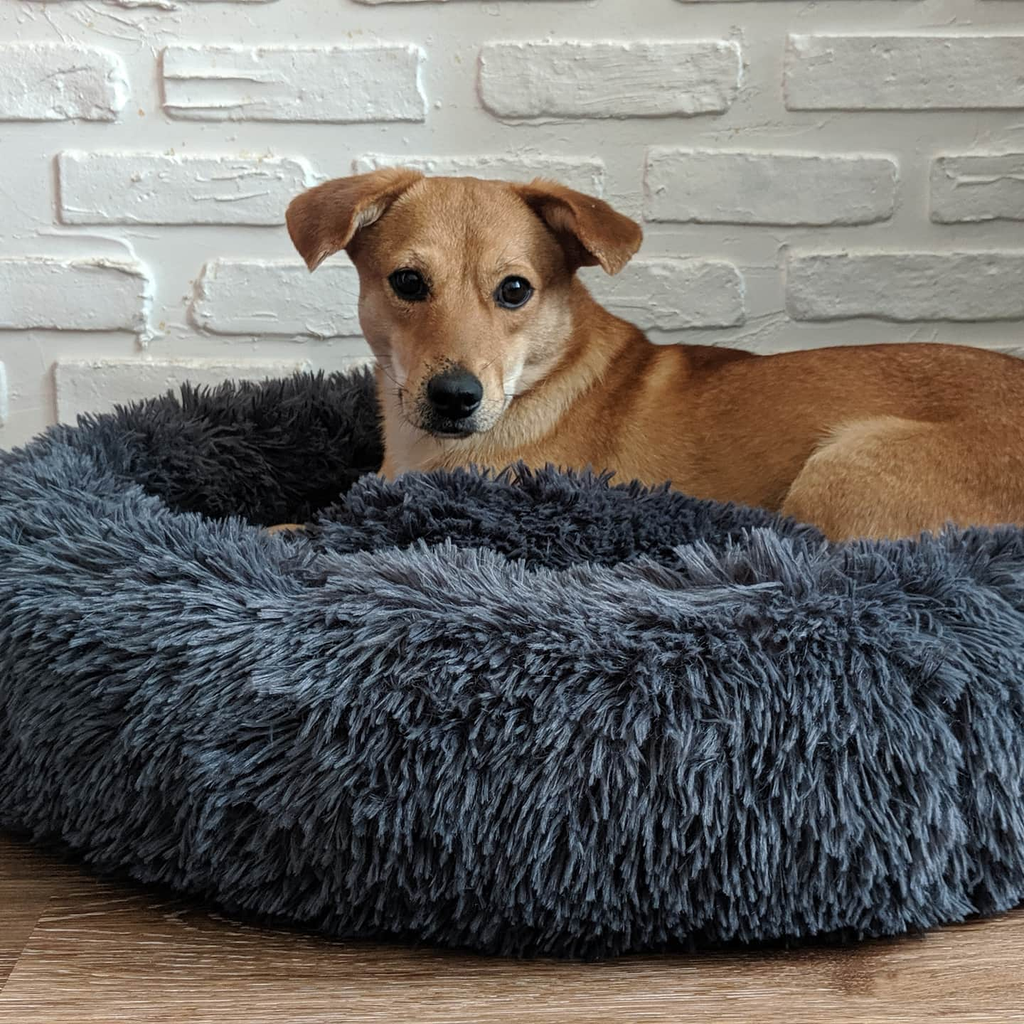

Data analysis entails several activities that are both qorthwhile and interesting at the same time, especially when it places you in a position to help businesses solve their issues. However, analyzing any dataset, especially when you have to deal with multiple data sources, coming up with relevant insights and being able to present same in a relatable, easy, and understandable form can be daunting. Working on the WeRateDogs project entailed a rigorous assessment of each data table that was used in the whole analysis. Since the project is about dogs and their ratings, it makes sense to observe several aspects including the dog names, their categories or stages, and their public acceptance measured by a proxy of favorites and retweets. All these necessitated the insights that were gotten from this project. The following part of this report shares some exciting insights and provides simple visualization to present the insights in a way that is more easily understandable.

```python
import pandas as pd
import matplotlib.pyplot as plt
import seaborn as sns
```

```python
gathered_accessed_cleaned = pd.read_csv("C:/Users/SURFACE LAPTOP 4/Downloads/twitter_archive_master.csv")
pd.set_option('display.max_columns', 50)
#gathered_accessed_cleaned.head(5)
```

# Insight 1: 296 dogs have no name. Cooper with 9 has the highest use

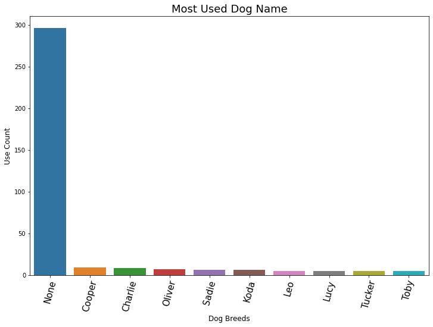

```python
plt.figure(figsize = (12,8))
ax = sns.barplot(x = gathered_accessed_cleaned.name.value_counts()[0:10].index,
            y = gathered_accessed_cleaned['name'].value_counts()[0:10],
            data = gathered_accessed_cleaned);
ax.set_xticklabels(ax.get_xticklabels(),rotation = 75, fontsize = 15);
plt.xlabel('Dog Breeds',fontsize = 12);
plt.ylabel('Use Count',fontsize = 12);
plt.title('Most Used Dog Name',fontsize = 18);
```